# Validation Design for Deep Learning Trading Strategies

This notebook examines how validation design affects the apparent performance of a deep-learning trading strategy. Bitcoin daily returns and a deliberately overlapping 10-day forward-return label are used, then three validation settings are compared:

1. a single chronological train/test split;
2. non-anchored walk-forward validation with the overlap left in place;
3. the same walk-forward designs after purging overlapping training labels.

The same three architectures are used throughout: an MLP, an LSTM, and a CNN applied to a Gramian Angular Field (GAF) representation.

### Reproducibility

A fixed random seed is used throughout so that the model comparisons are based on one reproducible execution.

```python
# Required packages
!pip -q install yfinance pyts
```

```python
import os
import warnings

os.environ["TF_CPP_MIN_LOG_LEVEL"] = "3"
warnings.filterwarnings("ignore")

import numpy as np
import pandas as pd
import matplotlib.pyplot as plt
import yfinance as yf
import tensorflow as tf

from sklearn.preprocessing import StandardScaler
from sklearn.metrics import mean_absolute_error, mean_squared_error
from pyts.image import GramianAngularField

from tensorflow.keras import Sequential
from tensorflow.keras.layers import (
    Input, Dense, Dropout, LSTM, Conv2D, MaxPooling2D, Flatten
)
from tensorflow.keras.callbacks import EarlyStopping
from tensorflow.keras.optimizers import Adam

# -----------------------------
# Global reproducibility settings
# -----------------------------
SEED = 642
np.random.seed(SEED)
tf.keras.utils.set_random_seed(SEED)
tf.get_logger().setLevel("ERROR")

try:
    tf.config.experimental.enable_op_determinism()
except Exception:
    pass

pd.set_option("display.max_columns", 30)
pd.set_option("display.float_format", lambda x: f"{x:,.6f}")
```

# Step 1a: Data description

We use daily Bitcoin (BTC-USD) prices and returns. The modelling sample is restricted to fewer than 2,000 observations, as required.

Bitcoin is useful for this exercise because the sample contains pronounced changes in both price level and volatility, providing a demanding setting for comparing validation schemes.

```python
TICKER = "BTC-USD"
RAW_OBS_LIMIT = 1900
N_LAGS = 30
N_FWD = 10
ANNUAL_FACTOR = 365.0

raw = yf.download(
    TICKER,
    start="2018-01-01",
    end="2026-01-01",
    interval="1d",
    auto_adjust=True,
    progress=False
)


if isinstance(raw.columns, pd.MultiIndex):
    raw.columns = raw.columns.get_level_values(0)

df = (
    raw[["Close"]]
    .rename(columns={"Close": "close"})
    .reset_index()
    .rename(columns={"Date": "date"})
    .tail(RAW_OBS_LIMIT)
    .reset_index(drop=True)
)

df["date"] = pd.to_datetime(df["date"]).dt.tz_localize(None)
df["Ret"] = df["close"].pct_change()
df = df.dropna().reset_index(drop=True)

print("Raw observations after return construction:", len(df))
print("Sample period:", df["date"].min().date(), "to", df["date"].max().date())
df.head()
```

```
Raw observations after return construction: 1899
Sample period: 2020-10-20 to 2025-12-31
```

| Price | date | close | Ret |
| --- | --- | --- | --- |
| 0 | 2020-10-20 | 11,916.334961 | 0.014844 |
| 1 | 2020-10-21 | 12,823.689453 | 0.076144 |
| 2 | 2020-10-22 | 12,965.891602 | 0.011089 |
| 3 | 2020-10-23 | 12,931.539062 | -0.002649 |
| 4 | 2020-10-24 | 13,108.062500 | 0.013651 |

### Price and return behaviour

The price and daily-return series are plotted below, followed by summary statistics for returns. Kurtosis is reported as **excess kurtosis**, for which the normal-distribution benchmark is zero.

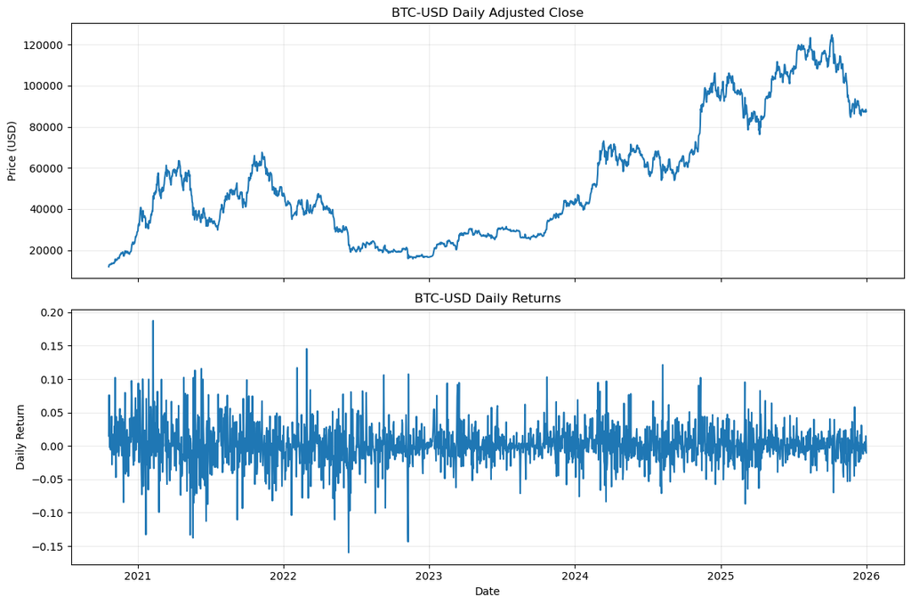

|  | BTC daily returns |
| --- | --- |
| Count | 1,899.000000 |
| Mean | 0.001531 |
| Std. Dev. | 0.030775 |
| Minimum | -0.159747 |
| 25% | -0.012980 |
| Median | 0.000313 |
| 75% | 0.015243 |
| Maximum | 0.187465 |
| Skewness | 0.151224 |
| Excess Kurtosis | 3.548208 |

```python
fig, axes = plt.subplots(2, 1, figsize=(12, 8), sharex=True)

axes[0].plot(df["date"], df["close"])
axes[0].set_title("BTC-USD Daily Adjusted Close")
axes[0].set_ylabel("Price (USD)")
axes[0].grid(alpha=0.25)

axes[1].plot(df["date"], df["Ret"])
axes[1].set_title("BTC-USD Daily Returns")
axes[1].set_xlabel("Date")
axes[1].set_ylabel("Daily Return")
axes[1].grid(alpha=0.25)

plt.tight_layout()
plt.show()

return_stats = pd.Series({
    "Count": df["Ret"].count(),
    "Mean": df["Ret"].mean(),
    "Std. Dev.": df["Ret"].std(),
    "Minimum": df["Ret"].min(),
    "25%": df["Ret"].quantile(0.25),
    "Median": df["Ret"].median(),
    "75%": df["Ret"].quantile(0.75),
    "Maximum": df["Ret"].max(),
    "Skewness": df["Ret"].skew(),
    "Excess Kurtosis": df["Ret"].kurt(),
}, name="BTC daily returns")

display(return_stats.to_frame())
```

# Step 1b: Deliberately overlapping labels

The target is the cumulative return over the next 10 daily observations:

$$ R_{t,t+10}=\prod_{j=1}^{10}(1+r_{t+j})-1. $$

Adjacent labels overlap heavily. For example, the label at $t$ uses returns from $t+1$ to $t+10$, while the label at $t+1$ uses $t+2$ to $t+11$. They therefore share nine of ten daily returns.

The source of leakage is this overlap **across a train/test boundary**: a training label near the boundary can contain return information that is also used to construct a test label. The start and end dates of each label window are retained so that this overlap can be measured directly.

```python
# Future returns r_{t+1}, ..., r_{t+10}
future_return_matrix = pd.concat(
    [df["Ret"].shift(-h) for h in range(1, N_FWD + 1)],
    axis=1
)
future_return_matrix.columns = [f"future_ret_{h}" for h in range(1, N_FWD + 1)]

df["Target_10d"] = (1.0 + future_return_matrix).prod(axis=1) - 1.0
df["LabelStart"] = df["date"].shift(-1)
df["LabelEnd"] = df["date"].shift(-N_FWD)

# Next-day return used in the trading backtest.
df["NextRet"] = df["Ret"].shift(-1)

df[["date", "Ret", "Target_10d", "LabelStart", "LabelEnd", "NextRet"]].tail(15)
```

| Price | date | Ret | Target_10d | LabelStart | LabelEnd | NextRet |
| --- | --- | --- | --- | --- | --- | --- |
| 1884 | 2025-12-17 | -0.019355 | 0.019252 | 2025-12-18 | 2025-12-27 | -0.007908 |
| 1885 | 2025-12-18 | -0.007908 | 0.027770 | 2025-12-19 | 2025-12-28 | 0.030901 |
| 1886 | 2025-12-19 | 0.030901 | -0.010956 | 2025-12-20 | 2025-12-29 | 0.002731 |
| 1887 | 2025-12-20 | 0.002731 | 0.000975 | 2025-12-21 | 2025-12-30 | 0.003144 |
| 1888 | 2025-12-21 | 0.003144 | -0.012558 | 2025-12-22 | 2025-12-31 | -0.001486 |
| 1889 | 2025-12-22 | -0.001486 | -0.011088 | 2025-12-23 | NaT | -0.012160 |
| 1890 | 2025-12-23 | -0.012160 | 0.001085 | 2025-12-24 | NaT | 0.002265 |
| 1891 | 2025-12-24 | 0.002265 | -0.001177 | 2025-12-25 | NaT | -0.004306 |
| 1892 | 2025-12-25 | -0.004306 | 0.003142 | 2025-12-26 | NaT | 0.000764 |
| 1893 | 2025-12-26 | 0.000764 | 0.002376 | 2025-12-27 | NaT | 0.005736 |
| 1894 | 2025-12-27 | 0.005736 | -0.003341 | 2025-12-28 | NaT | 0.000384 |
| 1895 | 2025-12-28 | 0.000384 | -0.003723 | 2025-12-29 | NaT | -0.007943 |
| 1896 | 2025-12-29 | -0.007943 | 0.004254 | 2025-12-30 | NaT | 0.014827 |
| 1897 | 2025-12-30 | 0.014827 | -0.010418 | 2025-12-31 | NaT | -0.010418 |
| 1898 | 2025-12-31 | -0.010418 | 0.000000 | NaT | NaT | NaN |

# Step 1c: Model inputs and trading rule

Each observation uses the most recent 30 daily returns to predict the 10-day forward cumulative return.

The information set is held constant across the three architectures:

- **MLP:** the 30 returns as a feature vector;
- **LSTM:** the same returns as an ordered (30\times1) sequence;
- **CNN-GAF:** the same window transformed into a (30\times30) GAF image.

For the GAF representation, each window is rescaled to ([-1,1]), mapped through

$ \phi_i=\arccos(\tilde{x}_i), $

and represented by

$ G_{ij}=\cos(\phi_i+\phi_j). $

All three models use the same trading rule: take a long position for the next day when the predicted 10-day return is positive; otherwise remain in cash.

```python
# Use the current return plus the previous 29 daily returns.
feature_cols = []
for lag in range(N_LAGS):
    col = f"Ret_lag_{lag}"
    df[col] = df["Ret"].shift(lag)
    feature_cols.append(col)

feat_df = df[
    ["date", "Ret", "NextRet", "Target_10d", "LabelStart", "LabelEnd"] + feature_cols
].dropna().reset_index(drop=True)

assert len(feat_df) <= 2000, "Assignment requires no more than 2,000 observations."

print("Final modelling observations:", len(feat_df))
print("Final modelling period:", feat_df["date"].min().date(), "to", feat_df["date"].max().date())
print("Input dimension:", len(feature_cols))
feat_df.head()
```

```
Final modelling observations: 1860
Final modelling period: 2020-11-18 to 2025-12-21
Input dimension: 30
```

| Price | date | Ret | NextRet | Target_10d | LabelStart | LabelEnd | Ret_lag_0 | Ret_lag_1 | Ret_lag_2 | Ret_lag_3 | Ret_lag_4 | Ret_lag_5 | Ret_lag_6 | Ret_lag_7 | Ret_lag_8 | ... | Ret_lag_15 | Ret_lag_16 | Ret_lag_17 | Ret_lag_18 | Ret_lag_19 | Ret_lag_20 | Ret_lag_21 | Ret_lag_22 | Ret_lag_23 | Ret_lag_24 | Ret_lag_25 | Ret_lag_26 | Ret_lag_27 | … |
| --- | --- | --- | --- | --- | --- | --- | --- | --- | --- | --- | --- | --- | --- | --- | --- | --- | --- | --- | --- | --- | --- | --- | --- | --- | --- | --- | --- | --- | --- | --- |
| 0 | 2020-11-18 | 0.008988 | 0.000735 | -0.004864 | 2020-11-19 | 2020-11-28 | 0.008988 | 0.055593 | 0.047665 | -0.007005 | -0.015300 | 0.002548 | 0.036621 | 0.026842 | -0.002701 | ... | 0.029505 | -0.013585 | -0.003185 | 0.017309 | 0.008085 | 0.012553 | -0.028045 | 0.044280 | 0.003382 | -0.005866 | 0.013651 | -0.002649 | 0.011089 | … |
| 1 | 2020-11-19 | 0.000735 | 0.045138 | 0.020227 | 2020-11-20 | 2020-11-29 | 0.000735 | 0.008988 | 0.055593 | 0.047665 | -0.007005 | -0.015300 | 0.002548 | 0.036621 | 0.026842 | ... | 0.013147 | 0.029505 | -0.013585 | -0.003185 | 0.017309 | 0.008085 | 0.012553 | -0.028045 | 0.044280 | 0.003382 | -0.005866 | 0.013651 | -0.002649 | … |
| 2 | 2020-11-20 | 0.045138 | 0.001123 | 0.053945 | 2020-11-21 | 2020-11-30 | 0.045138 | 0.000735 | 0.008988 | 0.055593 | 0.047665 | -0.007005 | -0.015300 | 0.002548 | 0.036621 | ... | 0.102319 | 0.013147 | 0.029505 | -0.013585 | -0.003185 | 0.017309 | 0.008085 | 0.012553 | -0.028045 | 0.044280 | 0.003382 | -0.005866 | 0.013651 | … |
| 3 | 2020-11-21 | 0.001123 | -0.014603 | 0.008624 | 2020-11-22 | 2020-12-01 | 0.001123 | 0.045138 | 0.000735 | 0.008988 | 0.055593 | 0.047665 | -0.007005 | -0.015300 | 0.002548 | ... | -0.000897 | 0.102319 | 0.013147 | 0.029505 | -0.013585 | -0.003185 | 0.017309 | 0.008085 | 0.012553 | -0.028045 | 0.044280 | 0.003382 | -0.005866 | … |
| 4 | 2020-11-22 | -0.014603 | -0.000320 | 0.045242 | 2020-11-23 | 2020-12-02 | -0.014603 | 0.001123 | 0.045138 | 0.000735 | 0.008988 | 0.055593 | 0.047665 | -0.007005 | -0.015300 | ... | -0.047034 | -0.000897 | 0.102319 | 0.013147 | 0.029505 | -0.013585 | -0.003185 | 0.017309 | 0.008085 | 0.012553 | -0.028045 | 0.044280 | 0.003382 | … |

5 rows × 36 columns

## Common estimation setup

The model architectures, loss function, optimizer, maximum epochs, batch size, trading rule, and evaluation metrics are held fixed across Steps 1-3.

A chronological validation tail is taken from each training sample for early stopping. The fitting portion is purged against that internal validation block so that model selection does not introduce an additional source of label overlap. The outer train/test boundary remains unpurged in Steps 1 and 2 and is treated explicitly in Step 3.

```python
MAX_EPOCHS = 35
PATIENCE = 5
BATCH_SIZE = 32
VAL_FRACTION = 0.15
LEARNING_RATE = 1e-3

gaf_transformer = GramianAngularField(
    image_size=N_LAGS,
    method="summation",
    sample_range=(-1, 1)
)

def build_model(model_name):
    tf.keras.backend.clear_session()

    if model_name == "MLP":
        model = Sequential([
            Input(shape=(N_LAGS,)),
            Dense(64, activation="relu"),
            Dropout(0.20),
            Dense(32, activation="relu"),
            Dense(1)
        ])

    elif model_name == "LSTM":
        model = Sequential([
            Input(shape=(N_LAGS, 1)),
            LSTM(32, return_sequences=True),
            Dropout(0.20),
            LSTM(16),
            Dense(1)
        ])

    elif model_name == "CNN-GAF":
        model = Sequential([
            Input(shape=(N_LAGS, N_LAGS, 1)),
            Conv2D(16, (3, 3), padding="same", activation="relu"),
            MaxPooling2D((2, 2)),
            Conv2D(32, (3, 3), padding="same", activation="relu"),
            MaxPooling2D((2, 2)),
            Flatten(),
            Dense(32, activation="relu"),
            Dropout(0.20),
            Dense(1)
        ])
    else:
        raise ValueError(f"Unknown model: {model_name}")

    model.compile(
        optimizer=Adam(learning_rate=LEARNING_RATE),
        loss="mse"
    )
    return model


def purge_against_test(train_df, test_df):
    """
    Remove training observations whose label interval overlaps the
    earliest label interval in the test set.

    In our non-anchored walk-forward design, all training observations
    precede the test block, so a post-test embargo is not required.
    """
    first_test_label_start = test_df["LabelStart"].iloc[0]
    keep = train_df["LabelEnd"] < first_test_label_start
    return train_df.loc[keep].copy()


def chronological_fit_validation_split(train_df, val_fraction=VAL_FRACTION):
    """
    Reserve the final part of an outer training fold for validation and
    purge fitting observations whose labels overlap that validation block.
    """
    split = int(len(train_df) * (1.0 - val_fraction))
    fit_df = train_df.iloc[:split].copy()
    val_df = train_df.iloc[split:].copy()

    if len(val_df) == 0:
        raise ValueError("Validation set is empty.")

    first_val_label_start = val_df["LabelStart"].iloc[0]
    fit_df = fit_df.loc[fit_df["LabelEnd"] < first_val_label_start].copy()

    return fit_df, val_df


def prepare_X(model_name, X_fit_raw, X_val_raw, X_test_raw):
    """
    Train-only preprocessing.

    MLP/LSTM: one StandardScaler is fit on all observed return values
    in the fitting sample, then reused for validation/test.
    CNN-GAF: each historical return window is transformed into a GAF;
    the transformation uses only values already inside that window.
    """
    if model_name in {"MLP", "LSTM"}:
        scaler = StandardScaler()
        scaler.fit(X_fit_raw.reshape(-1, 1))

        def transform(x):
            z = scaler.transform(x.reshape(-1, 1)).reshape(x.shape)
            if model_name == "LSTM":
                z = z[..., np.newaxis]
            return z

        return transform(X_fit_raw), transform(X_val_raw), transform(X_test_raw)

    if model_name == "CNN-GAF":
        X_fit = gaf_transformer.transform(X_fit_raw)[..., np.newaxis]
        X_val = gaf_transformer.transform(X_val_raw)[..., np.newaxis]
        X_test = gaf_transformer.transform(X_test_raw)[..., np.newaxis]
        return X_fit, X_val, X_test


def fit_predict(model_name, train_df, test_df, seed):
    """
    Fit one fresh model and return predictions in the original target scale.
    The outer test sample is never used for fitting, scaling, or early stopping.
    """
    tf.keras.utils.set_random_seed(seed)

    fit_df, val_df = chronological_fit_validation_split(train_df)

    X_fit_raw = fit_df[feature_cols].to_numpy(dtype=np.float32)
    X_val_raw = val_df[feature_cols].to_numpy(dtype=np.float32)
    X_test_raw = test_df[feature_cols].to_numpy(dtype=np.float32)

    y_fit_raw = fit_df["Target_10d"].to_numpy(dtype=np.float32).reshape(-1, 1)
    y_val_raw = val_df["Target_10d"].to_numpy(dtype=np.float32).reshape(-1, 1)

    X_fit, X_val, X_test = prepare_X(
        model_name, X_fit_raw, X_val_raw, X_test_raw
    )

    # Train-only target scaling improves numerical conditioning while
    # preserving a common target definition across architectures.
    y_scaler = StandardScaler()
    y_fit = y_scaler.fit_transform(y_fit_raw)
    y_val = y_scaler.transform(y_val_raw)

    model = build_model(model_name)

    early_stop = EarlyStopping(
        monitor="val_loss",
        patience=PATIENCE,
        restore_best_weights=True,
        min_delta=1e-5
    )

    history = model.fit(
        X_fit,
        y_fit,
        validation_data=(X_val, y_val),
        epochs=MAX_EPOCHS,
        batch_size=BATCH_SIZE,
        shuffle=False,
        verbose=0,
        callbacks=[early_stop]
    )

    pred_scaled = model.predict(X_test, verbose=0)
    pred = y_scaler.inverse_transform(pred_scaled).ravel()

    return pred, history


def prediction_frame(test_df, pred):
    out = test_df[
        ["date", "NextRet", "Target_10d", "LabelStart", "LabelEnd"]
    ].copy()
    out["prediction"] = np.asarray(pred)
    out["signal"] = (out["prediction"] > 0).astype(int)

    # The prediction at date t uses information available through t.
    # The position is therefore applied to the next daily return.
    out["strategy_ret"] = out["signal"] * out["NextRet"]
    out["buy_hold_ret"] = out["NextRet"]

    return out.reset_index(drop=True)


def predictive_metrics(pred_df):
    y = pred_df["Target_10d"].to_numpy()
    p = pred_df["prediction"].to_numpy()

    return {
        "MAE": mean_absolute_error(y, p),
        "MSE": mean_squared_error(y, p),
        "RMSE": np.sqrt(mean_squared_error(y, p)),
        "Directional Accuracy": np.mean(np.sign(y) == np.sign(p))
    }


def portfolio_metrics(daily_returns):
    r = pd.Series(daily_returns).dropna().astype(float)
    nav = (1.0 + r).cumprod()

    n = len(r)
    total_return = nav.iloc[-1] - 1.0
    annual_return = nav.iloc[-1] ** (ANNUAL_FACTOR / n) - 1.0
    annual_vol = r.std(ddof=1) * np.sqrt(ANNUAL_FACTOR)
    sharpe = (
        r.mean() / r.std(ddof=1) * np.sqrt(ANNUAL_FACTOR)
        if r.std(ddof=1) > 0 else np.nan
    )

    running_peak = nav.cummax().clip(lower=1.0)
    max_drawdown = (nav / running_peak - 1.0).min()

    return {
        "Total Return": total_return,
        "Annualized Return": annual_return,
        "Annualized Volatility": annual_vol,
        "Sharpe Ratio": sharpe,
        "Maximum Drawdown": max_drawdown
    }


def summarize_prediction_frame(pred_df, model_name, experiment):
    row = {
        "Experiment": experiment,
        "Model": model_name,
        "OOS Observations": len(pred_df),
    }
    row.update(predictive_metrics(pred_df))
    row.update(portfolio_metrics(pred_df["strategy_ret"]))

    bh = portfolio_metrics(pred_df["buy_hold_ret"])
    row["Buy-and-Hold Total Return"] = bh["Total Return"]
    row["Buy-and-Hold Sharpe"] = bh["Sharpe Ratio"]

    return row


def plot_strategy_comparison(predictions_by_model, title):
    plt.figure(figsize=(12, 6))

    # All models in one experiment share the same OOS dates.
    any_df = next(iter(predictions_by_model.values()))
    benchmark_nav = (1.0 + any_df["buy_hold_ret"]).cumprod()
    plt.plot(any_df["date"], benchmark_nav, linestyle="--", label="BTC Buy-and-Hold")

    for model_name, pred_df in predictions_by_model.items():
        nav = (1.0 + pred_df["strategy_ret"]).cumprod()
        plt.plot(pred_df["date"], nav, label=model_name)

    plt.title(title)
    plt.xlabel("Date")
    plt.ylabel("Growth of $1")
    plt.legend()
    plt.grid(alpha=0.25)
    plt.tight_layout()
    plt.show()
```

# Step 1c: Single train/test split

The first 80% of observations form the training sample and the final 20% form the test sample. The split is chronological.

No purging is applied at the outer boundary in this step. This preserves the deliberately overlapping labels required for the baseline experiment. Preprocessing parameters are estimated from the training data only, and the test sample is reserved for final out-of-sample evaluation.

The overlap count below reports how many training labels extend into the first test-label interval.

```python
split_idx = int(len(feat_df) * 0.80)

step1_train = feat_df.iloc[:split_idx].copy()
step1_test = feat_df.iloc[split_idx:].copy()

first_test_label_start = step1_test["LabelStart"].iloc[0]
step1_overlap_count = int(
    (step1_train["LabelEnd"] >= first_test_label_start).sum()
)

print("Training observations:", len(step1_train))
print("Test observations:", len(step1_test))
print("Train period:", step1_train["date"].min().date(), "to", step1_train["date"].max().date())
print("Test period:", step1_test["date"].min().date(), "to", step1_test["date"].max().date())
print("Training labels overlapping the test-label period:", step1_overlap_count)
```

```
Training observations: 1488
Test observations: 372
Train period: 2020-11-18 to 2024-12-14
Test period: 2024-12-15 to 2025-12-21
Training labels overlapping the test-label period: 9
```

## Step 1c: MLP, LSTM, and CNN-GAF results

The three models are estimated on the same training sample and evaluated on the same test period. Predictive accuracy and trading performance are reported on a common basis.

```python
MODEL_NAMES = ["MLP", "LSTM", "CNN-GAF"]

step1_predictions = {}
step1_histories = {}
step1_rows = []

for model_i, model_name in enumerate(MODEL_NAMES):
    print(f"Training Step 1 {model_name}...")

    pred, history = fit_predict(
        model_name,
        step1_train,
        step1_test,
        seed=SEED + 100 + model_i
    )

    pred_df = prediction_frame(step1_test, pred)
    step1_predictions[model_name] = pred_df
    step1_histories[model_name] = history
    step1_rows.append(
        summarize_prediction_frame(
            pred_df, model_name, "Step 1: Single Split (Leaky)"
        )
    )

step1_summary = pd.DataFrame(step1_rows)
display(step1_summary)
```

```
Training Step 1 MLP...
Training Step 1 LSTM...
Training Step 1 CNN-GAF...
```

|  | Experiment | Model | OOS Observations | MAE | MSE | RMSE | Directional Accuracy | Total Return | Annualized Return | Annualized Volatility | Sharpe Ratio | Maximum Drawdown | Buy-and-Hold Total Return | Buy-and-Hold Sharpe |
| --- | --- | --- | --- | --- | --- | --- | --- | --- | --- | --- | --- | --- | --- | --- |
| 0 | Step 1: Single Split (Leaky) | MLP | 372 | 0.049896 | 0.003997 | 0.063223 | 0.481183 | 0.041090 | 0.040302 | 0.331878 | 0.284285 | -0.263787 | -0.151571 | -0.167980 |
| 1 | Step 1: Single Split (Leaky) | LSTM | 372 | 0.049005 | 0.003687 | 0.060718 | 0.473118 | -0.151571 | -0.148943 | 0.424685 | -0.167980 | -0.321470 | -0.151571 | -0.167980 |
| 2 | Step 1: Single Split (Leaky) | CNN-GAF | 372 | 0.049785 | 0.003804 | 0.061680 | 0.473118 | -0.151571 | -0.148943 | 0.424685 | -0.167980 | -0.321470 | -0.151571 | -0.167980 |

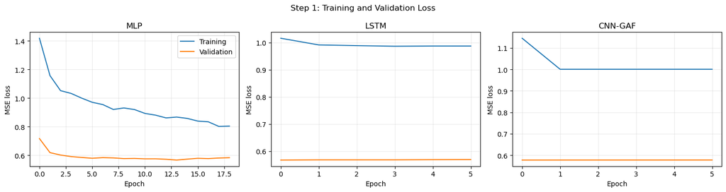

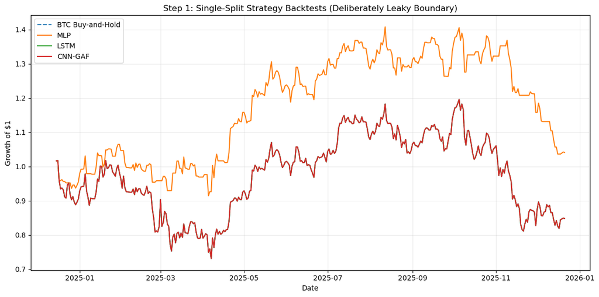

```python
# Training / validation histories
fig, axes = plt.subplots(1, 3, figsize=(15, 4))

for ax, model_name in zip(axes, MODEL_NAMES):
    hist = step1_histories[model_name].history
    ax.plot(hist["loss"], label="Training")
    ax.plot(hist["val_loss"], label="Validation")
    ax.set_title(model_name)
    ax.set_xlabel("Epoch")
    ax.set_ylabel("MSE loss")
    ax.grid(alpha=0.25)

axes[0].legend()
plt.suptitle("Step 1: Training and Validation Loss")
plt.tight_layout()
plt.show()

plot_strategy_comparison(
    step1_predictions,
    "Step 1: Single-Split Strategy Backtests (Deliberately Leaky Boundary)"
)
```

### Step 1c: Interpretation

Step 1 provides the single-split baseline. Because the label windows overlap at the train/test boundary, these results should be treated as potentially contaminated by leakage.

The three models differ only in how the same 30-day return history is represented. The comparison therefore provides a useful baseline for assessing whether later changes in performance are driven by architecture or by the validation design.

# Step 2: Non-anchored walk-forward backtesting

The same three models are re-estimated under two non-anchored walk-forward designs:

- **Step 2a:** 500 observations for training and 500 for testing;
- **Step 2b:** 500 observations for training and 100 for testing.

The training window remains fixed at 500 observations and rolls forward by the size of the test window. No outer purging is applied in Step 2, so the deliberately overlapping labels remain present.

```python
def run_walk_forward(model_name, train_size, test_size, purge_outer=False, seed_base=1000):
    fold_outputs = []
    leakage_rows = []

    n = len(feat_df)
    fold_id = 0

    for start in range(0, n - train_size - test_size + 1, test_size):
        train_end = start + train_size
        test_end = train_end + test_size

        train_fold_raw = feat_df.iloc[start:train_end].copy()
        test_fold = feat_df.iloc[train_end:test_end].copy()

        first_test_label_start = test_fold["LabelStart"].iloc[0]
        overlap_before = int(
            (train_fold_raw["LabelEnd"] >= first_test_label_start).sum()
        )

        if purge_outer:
            train_fold = purge_against_test(train_fold_raw, test_fold)
        else:
            train_fold = train_fold_raw

        overlap_after = int(
            (train_fold["LabelEnd"] >= first_test_label_start).sum()
        )

        pred, _ = fit_predict(
            model_name,
            train_fold,
            test_fold,
            seed=seed_base + fold_id
        )

        fold_df = prediction_frame(test_fold, pred)
        fold_df["Fold"] = fold_id + 1
        fold_outputs.append(fold_df)

        leakage_rows.append({
            "Model": model_name,
            "Fold": fold_id + 1,
            "Raw Train Size": len(train_fold_raw),
            "Effective Train Size": len(train_fold),
            "Test Size": len(test_fold),
            "Overlapping Train Labels Before": overlap_before,
            "Overlapping Train Labels After": overlap_after,
        })

        fold_id += 1

    predictions = pd.concat(fold_outputs, ignore_index=True)
    leakage = pd.DataFrame(leakage_rows)

    return predictions, leakage


def run_walk_forward_experiment(
    train_size,
    test_size,
    purge_outer,
    experiment_name,
    seed_offset
):
    preds_by_model = {}
    leakage_frames = []
    summary_rows = []

    for model_i, model_name in enumerate(MODEL_NAMES):
        print(f"{experiment_name}: training {model_name}...")

        preds, leakage = run_walk_forward(
            model_name=model_name,
            train_size=train_size,
            test_size=test_size,
            purge_outer=purge_outer,
            seed_base=SEED + seed_offset + model_i * 100
        )

        preds_by_model[model_name] = preds
        leakage_frames.append(leakage)
        summary_rows.append(
            summarize_prediction_frame(preds, model_name, experiment_name)
        )

    summary = pd.DataFrame(summary_rows)
    leakage = pd.concat(leakage_frames, ignore_index=True)

    return preds_by_model, summary, leakage
```

### Matched random initialization across walk-forward experiments

The same seed sequence is used for corresponding model/fold combinations in Steps 2 and 3. This keeps random initialization and dropout draws aligned across the unpurged and purged experiments, so the before/after comparison is driven by the change in the training sample rather than by a different stochastic fit.

## Step 2a: Walk Forward: 500 train / 500 test, unpurged

```
Step 2a: WF 500/500 (Leaky): training MLP...
Step 2a: WF 500/500 (Leaky): training LSTM...
Step 2a: WF 500/500 (Leaky): training CNN-GAF...
```

|  | Experiment | Model | OOS Observations | MAE | MSE | RMSE | Directional Accuracy | Total Return | Annualized Return | Annualized Volatility | Sharpe Ratio | Maximum Drawdown | Buy-and-Hold Total Return | Buy-and-Hold Sharpe |
| --- | --- | --- | --- | --- | --- | --- | --- | --- | --- | --- | --- | --- | --- | --- |
| 0 | Step 2a: WF 500/500 (Leaky) | MLP | 1000 | 0.073844 | 0.009939 | 0.099697 | 0.471000 | 0.098616 | 0.034925 | 0.420531 | 0.293061 | -0.646030 | 1.052911 | 0.760040 |
| 1 | Step 2a: WF 500/500 (Leaky) | LSTM | 1000 | 0.070438 | 0.009324 | 0.096560 | 0.479000 | -0.022912 | -0.008425 | 0.441511 | 0.202763 | -0.661382 | 1.052911 | 0.760040 |
| 2 | Step 2a: WF 500/500 (Leaky) | CNN-GAF | 1000 | 0.067587 | 0.008767 | 0.093634 | 0.545000 | 1.052911 | 0.300215 | 0.531734 | 0.760040 | -0.661382 | 1.052911 | 0.760040 |

| Model | Overlapping Train Labels Before | Overlapping Train Labels After |
| --- | --- | --- |
| CNN-GAF | 9.000000 | 9.000000 |
| LSTM | 9.000000 | 9.000000 |
| MLP | 9.000000 | 9.000000 |

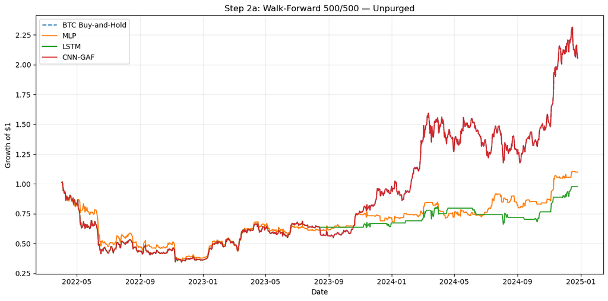

```python
step2a_predictions, step2a_summary, step2a_leakage = run_walk_forward_experiment(
    train_size=500,
    test_size=500,
    purge_outer=False,
    experiment_name="Step 2a: WF 500/500 (Leaky)",
    seed_offset=0
)

display(step2a_summary)
display(
    step2a_leakage.groupby("Model")[
        ["Overlapping Train Labels Before", "Overlapping Train Labels After"]
    ].mean()
)

plot_strategy_comparison(
    step2a_predictions,
    "Step 2a: Walk-Forward 500/500 — Unpurged"
)
```

## Step 2b: Walk Forward: 500 train / 100 test, unpurged

```
Step 2b: WF 500/100 (Leaky): training MLP...
Step 2b: WF 500/100 (Leaky): training LSTM...
Step 2b: WF 500/100 (Leaky): training CNN-GAF...
```

|  | Experiment | Model | OOS Observations | MAE | MSE | RMSE | Directional Accuracy | Total Return | Annualized Return | Annualized Volatility | Sharpe Ratio | Maximum Drawdown | Buy-and-Hold Total Return | Buy-and-Hold Sharpe |
| --- | --- | --- | --- | --- | --- | --- | --- | --- | --- | --- | --- | --- | --- | --- |
| 0 | Step 2b: WF 500/100 (Leaky) | MLP | 1300 | 0.066808 | 0.008283 | 0.091008 | 0.513846 | 1.054624 | 0.224068 | 0.401884 | 0.704251 | -0.532509 | 1.399657 | 0.738030 |
| 1 | Step 2b: WF 500/100 (Leaky) | LSTM | 1300 | 0.064627 | 0.008005 | 0.089470 | 0.508462 | 0.852238 | 0.188943 | 0.429751 | 0.617855 | -0.592095 | 1.399657 | 0.738030 |
| 2 | Step 2b: WF 500/100 (Leaky) | CNN-GAF | 1300 | 0.063244 | 0.007701 | 0.087756 | 0.541538 | 0.811174 | 0.181482 | 0.446164 | 0.597092 | -0.645881 | 1.399657 | 0.738030 |

| Model | Overlapping Train Labels Before | Overlapping Train Labels After |
| --- | --- | --- |
| CNN-GAF | 9.000000 | 9.000000 |
| LSTM | 9.000000 | 9.000000 |
| MLP | 9.000000 | 9.000000 |

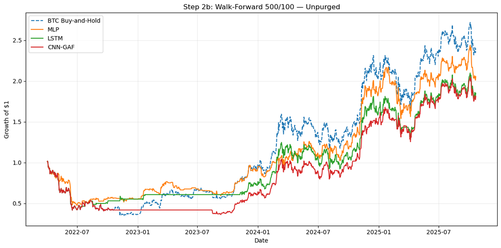

```python
step2b_predictions, step2b_summary, step2b_leakage = run_walk_forward_experiment(
    train_size=500,
    test_size=100,
    purge_outer=False,
    experiment_name="Step 2b: WF 500/100 (Leaky)",
    seed_offset=0
)

display(step2b_summary)
display(
    step2b_leakage.groupby("Model")[
        ["Overlapping Train Labels Before", "Overlapping Train Labels After"]
    ].mean()
)

plot_strategy_comparison(
    step2b_predictions,
    "Step 2b: Walk-Forward 500/100 — Unpurged"
)
```

## Step 2c: Comparison with Step 1

The table below compares the single-split baseline with both walk-forward designs for each architecture.

The main question is whether the conclusions from Step 1 remain stable when the models are re-estimated and tested across several chronological periods. A material change in predictive error or trading performance would indicate that the single split gives an incomplete picture of out-of-sample behaviour.

```python
step2_vs_step1 = pd.concat(
    [step1_summary, step2a_summary, step2b_summary],
    ignore_index=True
)

display(
    step2_vs_step1[
        [
            "Experiment", "Model", "OOS Observations",
            "MSE", "Directional Accuracy",
            "Annualized Return", "Sharpe Ratio", "Maximum Drawdown"
        ]
    ]
)

for model_name in MODEL_NAMES:
    sub = step2_vs_step1[step2_vs_step1["Model"] == model_name].set_index("Experiment")
    print(f"\n{model_name}")
    for experiment, row in sub.iterrows():
        print(
            f"  {experiment}: "
            f"MSE={row['MSE']:.6f}, "
            f"Sharpe={row['Sharpe Ratio']:.3f}, "
            f"Annualized Return={row['Annualized Return']:.2%}"
        )
```

|  | Experiment | Model | OOS Observations | MSE | Directional Accuracy | Annualized Return | Sharpe Ratio | Maximum Drawdown |
| --- | --- | --- | --- | --- | --- | --- | --- | --- |
| 0 | Step 1: Single Split (Leaky) | MLP | 372 | 0.003997 | 0.481183 | 0.040302 | 0.284285 | -0.263787 |
| 1 | Step 1: Single Split (Leaky) | LSTM | 372 | 0.003687 | 0.473118 | -0.148943 | -0.167980 | -0.321470 |
| 2 | Step 1: Single Split (Leaky) | CNN-GAF | 372 | 0.003804 | 0.473118 | -0.148943 | -0.167980 | -0.321470 |
| 3 | Step 2a: WF 500/500 (Leaky) | MLP | 1000 | 0.009939 | 0.471000 | 0.034925 | 0.293061 | -0.646030 |
| 4 | Step 2a: WF 500/500 (Leaky) | LSTM | 1000 | 0.009324 | 0.479000 | -0.008425 | 0.202763 | -0.661382 |
| 5 | Step 2a: WF 500/500 (Leaky) | CNN-GAF | 1000 | 0.008767 | 0.545000 | 0.300215 | 0.760040 | -0.661382 |
| 6 | Step 2b: WF 500/100 (Leaky) | MLP | 1300 | 0.008283 | 0.513846 | 0.224068 | 0.704251 | -0.532509 |
| 7 | Step 2b: WF 500/100 (Leaky) | LSTM | 1300 | 0.008005 | 0.508462 | 0.188943 | 0.617855 | -0.592095 |
| 8 | Step 2b: WF 500/100 (Leaky) | CNN-GAF | 1300 | 0.007701 | 0.541538 | 0.181482 | 0.597092 | -0.645881 |

```
MLP
  Step 1: Single Split (Leaky): MSE=0.003997, Sharpe=0.284, Annualized Return=4.03%
  Step 2a: WF 500/500 (Leaky): MSE=0.009939, Sharpe=0.293, Annualized Return=3.49%
  Step 2b: WF 500/100 (Leaky): MSE=0.008283, Sharpe=0.704, Annualized Return=22.41%

LSTM
  Step 1: Single Split (Leaky): MSE=0.003687, Sharpe=-0.168, Annualized Return=-14.89%
  Step 2a: WF 500/500 (Leaky): MSE=0.009324, Sharpe=0.203, Annualized Return=-0.84%
  Step 2b: WF 500/100 (Leaky): MSE=0.008005, Sharpe=0.618, Annualized Return=18.89%

CNN-GAF
  Step 1: Single Split (Leaky): MSE=0.003804, Sharpe=-0.168, Annualized Return=-14.89%
  Step 2a: WF 500/500 (Leaky): MSE=0.008767, Sharpe=0.760, Annualized Return=30.02%
  Step 2b: WF 500/100 (Leaky): MSE=0.007701, Sharpe=0.597, Annualized Return=18.15%
```

## Step 2d: 500/500 versus 500/100

The 500/100 design retrains the models more frequently and therefore creates more train/test boundaries. With overlapping 10-day labels, this also creates more occasions on which boundary leakage can arise.

The two window choices are compared using predictive error, risk-adjusted performance, and the measured number of overlapping labels. No direction of performance change is assumed in advance.

```python
step2_window_comparison = pd.concat(
    [step2a_summary, step2b_summary],
    ignore_index=True
)

display(
    step2_window_comparison[
        [
            "Experiment", "Model", "OOS Observations",
            "MSE", "RMSE", "Directional Accuracy",
            "Total Return", "Annualized Return",
            "Sharpe Ratio", "Maximum Drawdown"
        ]
    ]
)

step2_leakage_comparison = pd.concat(
    [
        step2a_leakage.assign(Experiment="500/500"),
        step2b_leakage.assign(Experiment="500/100")
    ],
    ignore_index=True
)

display(
    step2_leakage_comparison.groupby(["Experiment", "Model"])[
        ["Overlapping Train Labels Before", "Overlapping Train Labels After"]
    ].agg(["mean", "max"])
)
```

|  | Experiment | Model | OOS Observations | MSE | RMSE | Directional Accuracy | Total Return | Annualized Return | Sharpe Ratio | Maximum Drawdown |
| --- | --- | --- | --- | --- | --- | --- | --- | --- | --- | --- |
| 0 | Step 2a: WF 500/500 (Leaky) | MLP | 1000 | 0.009939 | 0.099697 | 0.471000 | 0.098616 | 0.034925 | 0.293061 | -0.646030 |
| 1 | Step 2a: WF 500/500 (Leaky) | LSTM | 1000 | 0.009324 | 0.096560 | 0.479000 | -0.022912 | -0.008425 | 0.202763 | -0.661382 |
| 2 | Step 2a: WF 500/500 (Leaky) | CNN-GAF | 1000 | 0.008767 | 0.093634 | 0.545000 | 1.052911 | 0.300215 | 0.760040 | -0.661382 |
| 3 | Step 2b: WF 500/100 (Leaky) | MLP | 1300 | 0.008283 | 0.091008 | 0.513846 | 1.054624 | 0.224068 | 0.704251 | -0.532509 |
| 4 | Step 2b: WF 500/100 (Leaky) | LSTM | 1300 | 0.008005 | 0.089470 | 0.508462 | 0.852238 | 0.188943 | 0.617855 | -0.592095 |
| 5 | Step 2b: WF 500/100 (Leaky) | CNN-GAF | 1300 | 0.007701 | 0.087756 | 0.541538 | 0.811174 | 0.181482 | 0.597092 | -0.645881 |

| Experiment | Model | Overlapping Train Labels Before mean | Overlapping Train Labels Before max | Overlapping Train Labels After mean | Overlapping Train Labels After max |
| --- | --- | --- | --- | --- | --- |
| 500/100 | CNN-GAF | 9.000000 | 9 | 9.000000 | 9 |
|  | LSTM | 9.000000 | 9 | 9.000000 | 9 |
|  | MLP | 9.000000 | 9 | 9.000000 | 9 |
| 500/500 | CNN-GAF | 9.000000 | 9 | 9.000000 | 9 |
|  | LSTM | 9.000000 | 9 | 9.000000 | 9 |
|  | MLP | 9.000000 | 9 | 9.000000 | 9 |

# Step 3a: Leakage reduction by purging

For each walk-forward fold, training observations are removed when their label interval overlaps the first test-label interval. Formally, a training observation (i) is retained only when

$ t_{i,1}<t_{j,0}, $

where $t_{i,1}$ is the end of its label window and $t_{j,0}$ is the start of the first test label.

This is the purging procedure described in the course material: observations whose labels use information contained in the test period are excluded from the training sample.

An embargo is not required in this specific rolling design because every training block lies entirely before its corresponding test block; there are no post-test training observations in the same fold.

## Step 3b: Purged Walk Forward: 500 train / 500 test

```
Step 3b: WF 500/500 (Purged): training MLP...
Step 3b: WF 500/500 (Purged): training LSTM...
Step 3b: WF 500/500 (Purged): training CNN-GAF...
```

|  | Experiment | Model | OOS Observations | MAE | MSE | RMSE | Directional Accuracy | Total Return | Annualized Return | Annualized Volatility | Sharpe Ratio | Maximum Drawdown | Buy-and-Hold Total Return | Buy-and-Hold Sharpe |
| --- | --- | --- | --- | --- | --- | --- | --- | --- | --- | --- | --- | --- | --- | --- |
| 0 | Step 3b: WF 500/500 (Purged) | MLP | 1000 | 0.073060 | 0.009776 | 0.098874 | 0.472000 | -0.079927 | -0.029948 | 0.421325 | 0.140091 | -0.650671 | 1.052911 | 0.760040 |
| 1 | Step 3b: WF 500/500 (Purged) | LSTM | 1000 | 0.070803 | 0.009391 | 0.096908 | 0.475000 | -0.175159 | -0.067873 | 0.436031 | 0.058218 | -0.661382 | 1.052911 | 0.760040 |
| 2 | Step 3b: WF 500/500 (Purged) | CNN-GAF | 1000 | 0.065551 | 0.008310 | 0.091161 | 0.543000 | 1.140282 | 0.320146 | 0.526281 | 0.791377 | -0.689396 | 1.052911 | 0.760040 |

| Model | Raw Train Size | Effective Train Size | Overlapping Train Labels Before | Overlapping Train Labels After |
| --- | --- | --- | --- | --- |
| CNN-GAF | 500.000000 | 491.000000 | 9.000000 | 0.000000 |
| LSTM | 500.000000 | 491.000000 | 9.000000 | 0.000000 |
| MLP | 500.000000 | 491.000000 | 9.000000 | 0.000000 |

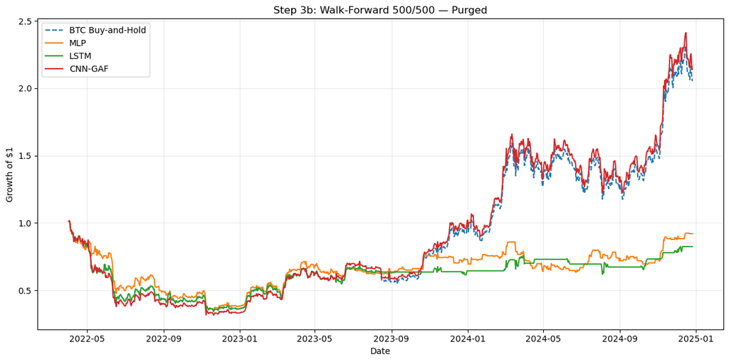

```python
step3b_predictions, step3b_summary, step3b_leakage = run_walk_forward_experiment(
    train_size=500,
    test_size=500,
    purge_outer=True,
    experiment_name="Step 3b: WF 500/500 (Purged)",
    seed_offset=0
)

display(step3b_summary)
display(
    step3b_leakage.groupby("Model")[
        [
            "Raw Train Size", "Effective Train Size",
            "Overlapping Train Labels Before",
            "Overlapping Train Labels After"
        ]
    ].mean()
)

plot_strategy_comparison(
    step3b_predictions,
    "Step 3b: Walk-Forward 500/500 — Purged"
)
```

## Step 3c: Purged Walk Forward: 500 train / 100 test

```
Step 3c: WF 500/100 (Purged): training MLP...
Step 3c: WF 500/100 (Purged): training LSTM...
Step 3c: WF 500/100 (Purged): training CNN-GAF...
```

|  | Experiment | Model | OOS Observations | MAE | MSE | RMSE | Directional Accuracy | Total Return | Annualized Return | Annualized Volatility | Sharpe Ratio | Maximum Drawdown | Buy-and-Hold Total Return | Buy-and-Hold Sharpe |
| --- | --- | --- | --- | --- | --- | --- | --- | --- | --- | --- | --- | --- | --- | --- |
| 0 | Step 3c: WF 500/100 (Purged) | MLP | 1300 | 0.066654 | 0.008266 | 0.090918 | 0.520000 | 1.090251 | 0.229991 | 0.401265 | 0.716696 | -0.530241 | 1.399657 | 0.738030 |
| 1 | Step 3c: WF 500/100 (Purged) | LSTM | 1300 | 0.066263 | 0.008610 | 0.092793 | 0.508462 | 0.825554 | 0.184109 | 0.429517 | 0.608472 | -0.592095 | 1.399657 | 0.738030 |
| 2 | Step 3c: WF 500/100 (Purged) | CNN-GAF | 1300 | 0.063279 | 0.007594 | 0.087143 | 0.535385 | 0.441486 | 0.108126 | 0.446693 | 0.453502 | -0.675178 | 1.399657 | 0.738030 |

| Model | Raw Train Size | Effective Train Size | Overlapping Train Labels Before | Overlapping Train Labels After |
| --- | --- | --- | --- | --- |
| CNN-GAF | 500.000000 | 491.000000 | 9.000000 | 0.000000 |
| LSTM | 500.000000 | 491.000000 | 9.000000 | 0.000000 |
| MLP | 500.000000 | 491.000000 | 9.000000 | 0.000000 |

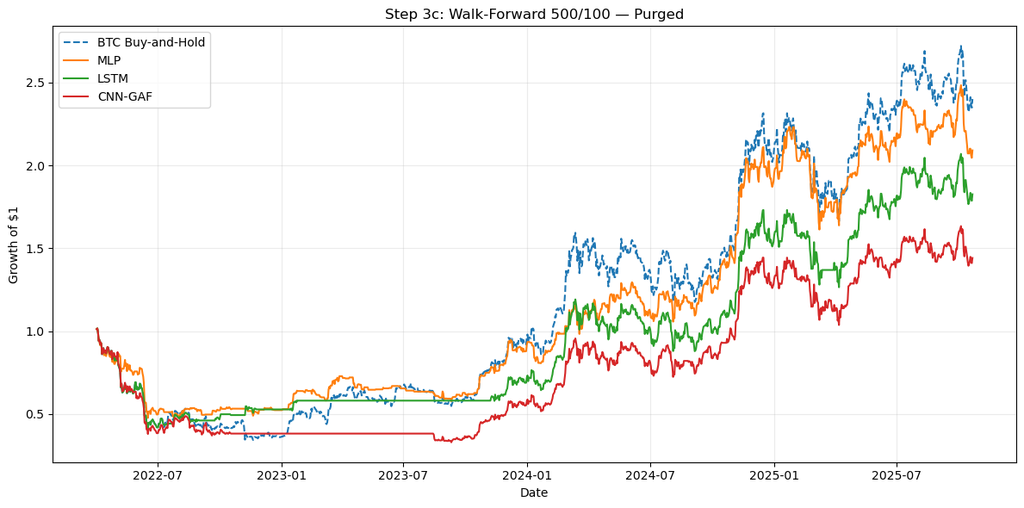

```python
step3c_predictions, step3c_summary, step3c_leakage = run_walk_forward_experiment(
    train_size=500,
    test_size=100,
    purge_outer=True,
    experiment_name="Step 3c: WF 500/100 (Purged)",
    seed_offset=0
)

display(step3c_summary)
display(
    step3c_leakage.groupby("Model")[
        [
            "Raw Train Size", "Effective Train Size",
            "Overlapping Train Labels Before",
            "Overlapping Train Labels After"
        ]
    ].mean()
)

plot_strategy_comparison(
    step3c_predictions,
    "Step 3c: Walk-Forward 500/100 — Purged"
)
```

# Step 3d: Purged versus unpurged results

The comparison below addresses whether the apparent overfitting associated with overlapping labels is reduced after purging.

Two pieces of evidence are used:

1. the overlap audit confirms whether any training-label interval still enters the test-label period;
2. predictive and trading results are compared with the otherwise identical unpurged walk-forward experiments.

Purging removes a known source of contamination, but it does not imply that performance must fall mechanically. The relevant question is whether the measured results remain stable once the overlap has been removed.

```python
step3_comparison = pd.concat(
    [
        step2a_summary,
        step3b_summary,
        step2b_summary,
        step3c_summary
    ],
    ignore_index=True
)

display(
    step3_comparison[
        [
            "Experiment", "Model", "OOS Observations",
            "MSE", "Directional Accuracy",
            "Total Return", "Annualized Return",
            "Sharpe Ratio", "Maximum Drawdown"
        ]
    ]
)

# Direct before/after changes for each window and model.
pairs = [
    ("500/500", step2a_summary, step3b_summary),
    ("500/100", step2b_summary, step3c_summary),
]

change_rows = []
for window, leaky_summary, purged_summary in pairs:
    left = leaky_summary.set_index("Model")
    right = purged_summary.set_index("Model")

    for model_name in MODEL_NAMES:
        change_rows.append({
            "Window": window,
            "Model": model_name,
            "Leaky MSE": left.loc[model_name, "MSE"],
            "Purged MSE": right.loc[model_name, "MSE"],
            "Change in MSE (%)":
                (right.loc[model_name, "MSE"] / left.loc[model_name, "MSE"] - 1.0) * 100,
            "Leaky Sharpe": left.loc[model_name, "Sharpe Ratio"],
            "Purged Sharpe": right.loc[model_name, "Sharpe Ratio"],
            "Change in Sharpe":
                right.loc[model_name, "Sharpe Ratio"] - left.loc[model_name, "Sharpe Ratio"],
            "Leaky Annual Return": left.loc[model_name, "Annualized Return"],
            "Purged Annual Return": right.loc[model_name, "Annualized Return"],
        })

purging_effect = pd.DataFrame(change_rows)
display(purging_effect)

print("\nLeakage verification after purging:")
for name, leakage_df in {
    "Step 3b 500/500": step3b_leakage,
    "Step 3c 500/100": step3c_leakage,
}.items():
    print(
        f"{name}: maximum overlapping training labels after purge = "
        f"{leakage_df['Overlapping Train Labels After'].max()}"
    )
```

|  | Experiment | Model | OOS Observations | MSE | Directional Accuracy | Total Return | Annualized Return | Sharpe Ratio | Maximum Drawdown |
| --- | --- | --- | --- | --- | --- | --- | --- | --- | --- |
| 0 | Step 2a: WF 500/500 (Leaky) | MLP | 1000 | 0.009939 | 0.471000 | 0.098616 | 0.034925 | 0.293061 | -0.646030 |
| 1 | Step 2a: WF 500/500 (Leaky) | LSTM | 1000 | 0.009324 | 0.479000 | -0.022912 | -0.008425 | 0.202763 | -0.661382 |
| 2 | Step 2a: WF 500/500 (Leaky) | CNN-GAF | 1000 | 0.008767 | 0.545000 | 1.052911 | 0.300215 | 0.760040 | -0.661382 |
| 3 | Step 3b: WF 500/500 (Purged) | MLP | 1000 | 0.009776 | 0.472000 | -0.079927 | -0.029948 | 0.140091 | -0.650671 |
| 4 | Step 3b: WF 500/500 (Purged) | LSTM | 1000 | 0.009391 | 0.475000 | -0.175159 | -0.067873 | 0.058218 | -0.661382 |
| 5 | Step 3b: WF 500/500 (Purged) | CNN-GAF | 1000 | 0.008310 | 0.543000 | 1.140282 | 0.320146 | 0.791377 | -0.689396 |
| 6 | Step 2b: WF 500/100 (Leaky) | MLP | 1300 | 0.008283 | 0.513846 | 1.054624 | 0.224068 | 0.704251 | -0.532509 |
| 7 | Step 2b: WF 500/100 (Leaky) | LSTM | 1300 | 0.008005 | 0.508462 | 0.852238 | 0.188943 | 0.617855 | -0.592095 |
| 8 | Step 2b: WF 500/100 (Leaky) | CNN-GAF | 1300 | 0.007701 | 0.541538 | 0.811174 | 0.181482 | 0.597092 | -0.645881 |
| 9 | Step 3c: WF 500/100 (Purged) | MLP | 1300 | 0.008266 | 0.520000 | 1.090251 | 0.229991 | 0.716696 | -0.530241 |
| 10 | Step 3c: WF 500/100 (Purged) | LSTM | 1300 | 0.008610 | 0.508462 | 0.825554 | 0.184109 | 0.608472 | -0.592095 |
| 11 | Step 3c: WF 500/100 (Purged) | CNN-GAF | 1300 | 0.007594 | 0.535385 | 0.441486 | 0.108126 | 0.453502 | -0.675178 |

|  | Window | Model | Leaky MSE | Purged MSE | Change in MSE (%) | Leaky Sharpe | Purged Sharpe | Change in Sharpe | Leaky Annual Return | Purged Annual Return |
| --- | --- | --- | --- | --- | --- | --- | --- | --- | --- | --- |
| 0 | 500/500 | MLP | 0.009939 | 0.009776 | -1.643265 | 0.293061 | 0.140091 | -0.152970 | 0.034925 | -0.029948 |
| 1 | 500/500 | LSTM | 0.009324 | 0.009391 | 0.721912 | 0.202763 | 0.058218 | -0.144544 | -0.008425 | -0.067873 |
| 2 | 500/500 | CNN-GAF | 0.008767 | 0.008310 | -5.212582 | 0.760040 | 0.791377 | 0.031337 | 0.300215 | 0.320146 |
| 3 | 500/100 | MLP | 0.008283 | 0.008266 | -0.198468 | 0.704251 | 0.716696 | 0.012445 | 0.224068 | 0.229991 |
| 4 | 500/100 | LSTM | 0.008005 | 0.008610 | 7.566399 | 0.617855 | 0.608472 | -0.009383 | 0.188943 | 0.184109 |
| 5 | 500/100 | CNN-GAF | 0.007701 | 0.007594 | -1.391511 | 0.597092 | 0.453502 | -0.143590 | 0.181482 | 0.108126 |

```
Leakage verification after purging:
Step 3b 500/500: maximum overlapping training labels after purge = 0
Step 3c 500/100: maximum overlapping training labels after purge = 0
```

# Consolidated comparison — Steps 1 to 3

Across the full experiment, no architecture dominates under every validation design. CNN-GAF is strongest under the purged 500/500 specification, while the MLP is strongest under purged 500/100. The LSTM generally produces competitive forecast errors but does not convert that advantage into the strongest trading results.

The main finding is therefore about validation rather than model ranking. The same underlying prediction problem produces materially different economic conclusions under a single split, rolling windows, and purged rolling windows. This is precisely why the treatment of overlapping financial labels is part of the model-evaluation problem rather than a separate implementation detail.

```python
all_results = pd.concat(
    [
        step1_summary,
        step2a_summary,
        step2b_summary,
        step3b_summary,
        step3c_summary
    ],
    ignore_index=True
)

display(
    all_results[
        [
            "Experiment", "Model", "OOS Observations",
            "MAE", "MSE", "RMSE", "Directional Accuracy",
            "Total Return", "Annualized Return",
            "Annualized Volatility", "Sharpe Ratio",
            "Maximum Drawdown",
            "Buy-and-Hold Total Return", "Buy-and-Hold Sharpe"
        ]
    ]
)

# Export consolidated tables for the report.
all_results.to_csv("gwp2_all_results.csv", index=False)
purging_effect.to_csv("gwp2_purging_effect.csv", index=False)

print("Saved optional report-support tables:")
print(" - gwp2_all_results.csv")
print(" - gwp2_purging_effect.csv")
```

|  | Experiment | Model | OOS Observations | MAE | MSE | RMSE | Directional Accuracy | Total Return | Annualized Return | Annualized Volatility | Sharpe Ratio | Maximum Drawdown | Buy-and-Hold Total Return | Buy-and-Hold Sharpe |
| --- | --- | --- | --- | --- | --- | --- | --- | --- | --- | --- | --- | --- | --- | --- |
| 0 | Step 1: Single Split (Leaky) | MLP | 372 | 0.049896 | 0.003997 | 0.063223 | 0.481183 | 0.041090 | 0.040302 | 0.331878 | 0.284285 | -0.263787 | -0.151571 | -0.167980 |
| 1 | Step 1: Single Split (Leaky) | LSTM | 372 | 0.049005 | 0.003687 | 0.060718 | 0.473118 | -0.151571 | -0.148943 | 0.424685 | -0.167980 | -0.321470 | -0.151571 | -0.167980 |
| 2 | Step 1: Single Split (Leaky) | CNN-GAF | 372 | 0.049785 | 0.003804 | 0.061680 | 0.473118 | -0.151571 | -0.148943 | 0.424685 | -0.167980 | -0.321470 | -0.151571 | -0.167980 |
| 3 | Step 2a: WF 500/500 (Leaky) | MLP | 1000 | 0.073844 | 0.009939 | 0.099697 | 0.471000 | 0.098616 | 0.034925 | 0.420531 | 0.293061 | -0.646030 | 1.052911 | 0.760040 |
| 4 | Step 2a: WF 500/500 (Leaky) | LSTM | 1000 | 0.070438 | 0.009324 | 0.096560 | 0.479000 | -0.022912 | -0.008425 | 0.441511 | 0.202763 | -0.661382 | 1.052911 | 0.760040 |
| 5 | Step 2a: WF 500/500 (Leaky) | CNN-GAF | 1000 | 0.067587 | 0.008767 | 0.093634 | 0.545000 | 1.052911 | 0.300215 | 0.531734 | 0.760040 | -0.661382 | 1.052911 | 0.760040 |
| 6 | Step 2b: WF 500/100 (Leaky) | MLP | 1300 | 0.066808 | 0.008283 | 0.091008 | 0.513846 | 1.054624 | 0.224068 | 0.401884 | 0.704251 | -0.532509 | 1.399657 | 0.738030 |
| 7 | Step 2b: WF 500/100 (Leaky) | LSTM | 1300 | 0.064627 | 0.008005 | 0.089470 | 0.508462 | 0.852238 | 0.188943 | 0.429751 | 0.617855 | -0.592095 | 1.399657 | 0.738030 |
| 8 | Step 2b: WF 500/100 (Leaky) | CNN-GAF | 1300 | 0.063244 | 0.007701 | 0.087756 | 0.541538 | 0.811174 | 0.181482 | 0.446164 | 0.597092 | -0.645881 | 1.399657 | 0.738030 |
| 9 | Step 3b: WF 500/500 (Purged) | MLP | 1000 | 0.073060 | 0.009776 | 0.098874 | 0.472000 | -0.079927 | -0.029948 | 0.421325 | 0.140091 | -0.650671 | 1.052911 | 0.760040 |
| 10 | Step 3b: WF 500/500 (Purged) | LSTM | 1000 | 0.070803 | 0.009391 | 0.096908 | 0.475000 | -0.175159 | -0.067873 | 0.436031 | 0.058218 | -0.661382 | 1.052911 | 0.760040 |
| 11 | Step 3b: WF 500/500 (Purged) | CNN-GAF | 1000 | 0.065551 | 0.008310 | 0.091161 | 0.543000 | 1.140282 | 0.320146 | 0.526281 | 0.791377 | -0.689396 | 1.052911 | 0.760040 |
| 12 | Step 3c: WF 500/100 (Purged) | MLP | 1300 | 0.066654 | 0.008266 | 0.090918 | 0.520000 | 1.090251 | 0.229991 | 0.401265 | 0.716696 | -0.530241 | 1.399657 | 0.738030 |
| 13 | Step 3c: WF 500/100 (Purged) | LSTM | 1300 | 0.066263 | 0.008610 | 0.092793 | 0.508462 | 0.825554 | 0.184109 | 0.429517 | 0.608472 | -0.592095 | 1.399657 | 0.738030 |
| 14 | Step 3c: WF 500/100 (Purged) | CNN-GAF | 1300 | 0.063279 | 0.007594 | 0.087143 | 0.535385 | 0.441486 | 0.108126 | 0.446693 | 0.453502 | -0.675178 | 1.399657 | 0.738030 |

```
Saved optional report-support tables:
 - gwp2_all_results.csv
 - gwp2_purging_effect.csv
```

| Model Experiment | CNN-GAF | LSTM | MLP |
| --- | --- | --- | --- |
| Step 1: Single Split (Leaky) | -0.167980 | -0.167980 | 0.284285 |
| Step 2a: WF 500/500 (Leaky) | 0.760040 | 0.202763 | 0.293061 |
| Step 2b: WF 500/100 (Leaky) | 0.597092 | 0.617855 | 0.704251 |
| Step 3b: WF 500/500 (Purged) | 0.791377 | 0.058218 | 0.140091 |
| Step 3c: WF 500/100 (Purged) | 0.453502 | 0.608472 | 0.716696 |

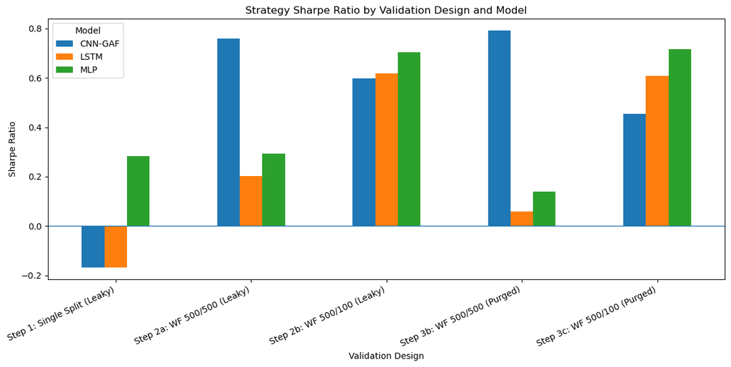

```python
# Compact visual summary of Sharpe ratios across all experiments.
sharpe_table = all_results.pivot(
    index="Experiment",
    columns="Model",
    values="Sharpe Ratio"
)

display(sharpe_table)

ax = sharpe_table.plot(kind="bar", figsize=(12, 6))
ax.set_title("Strategy Sharpe Ratio by Validation Design and Model")
ax.set_xlabel("Validation Design")
ax.set_ylabel("Sharpe Ratio")
ax.axhline(0, linewidth=1)
plt.xticks(rotation=25, ha="right")
plt.tight_layout()
plt.show()
```